# Project Proposal: Happiness Report’s top tier for multiple consecutive years

# Preliminary Results

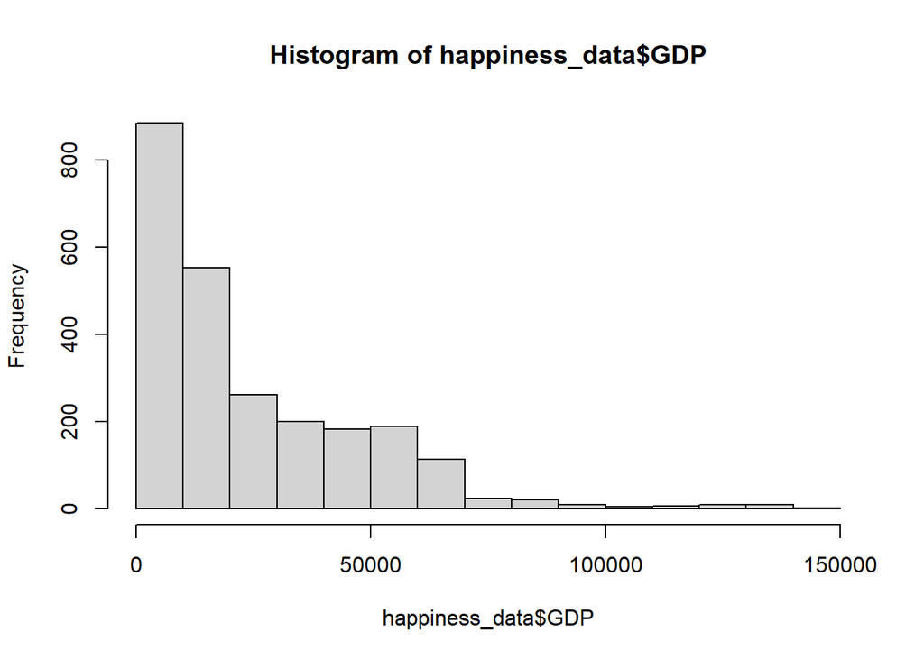

```
##  Country_name            Year       Ladder_score        Rank
##  Length:2283        Min.   :2005   Min.   :1.281   Min.   :  1.00
##  Class :character   1st Qu.:2011   1st Qu.:4.612   1st Qu.: 33.00
##  Mode  :character   Median :2015   Median :5.438   Median : 66.00
##                     Mean   :2015   Mean   :5.465   Mean   : 67.28
##                     3rd Qu.:2020   3rd Qu.:6.309   3rd Qu.:100.00
##                     Max.   :2024   Max.   :8.019   Max.   :147.00
##    Inequality   Social_support        GDP         Life_expectancy
##  Min.   :0.90   Min.   :0.2280   Min.   :   275   Min.   :35.30
##  1st Qu.:1.80   1st Qu.:0.7375   1st Qu.:  5597   1st Qu.:58.48
##  Median :2.10   Median :0.8330   Median : 15105   Median :64.14
##  Mean   :2.12   Mean   :0.8067   Mean   : 23223   Mean   :62.63
##  3rd Qu.:2.40   3rd Qu.:0.9050   3rd Qu.: 35080   3rd Qu.:67.50
##  Max.   :4.10   Max.   :0.9880   Max.   :145591   Max.   :73.80
##     Freedom         Generosity       Corruption      Pos_emotions
##  Min.   :0.2280   Min.   :0.0030   Min.   :0.0350   Min.   :0.179
##  1st Qu.:0.6620   1st Qu.:0.1670   1st Qu.:0.6900   1st Qu.:0.573
##  Median :0.7730   Median :0.2560   Median :0.8000   Median :0.664
##  Mean   :0.7522   Mean   :0.3007   Mean   :0.7463   Mean   :0.653
##  3rd Qu.:0.8630   3rd Qu.:0.4005   3rd Qu.:0.8670   3rd Qu.:0.740
##  Max.   :0.9850   Max.   :0.9190   Max.   :0.9830   Max.   :0.884
##   Neg_emotions       Donated        Volunteered     Helped_stranger
##  Min.   :0.0980   Min.   :0.0030   Min.   :0.0180   Min.   :0.1140
##  1st Qu.:0.2130   1st Qu.:0.1670   1st Qu.:0.1300   1st Qu.:0.4070
##  Median :0.2650   Median :0.2560   Median :0.1990   Median :0.5090
##  Mean   :0.2763   Mean   :0.3007   Mean   :0.2124   Mean   :0.5074
##  3rd Qu.:0.3290   3rd Qu.:0.4005   3rd Qu.:0.2792   3rd Qu.:0.6075
##  Max.   :0.7050   Max.   :0.9190   Max.   :0.6540   Max.   :0.8740
##    Top_20          Top_15          Top_25          Top20_Last
##  Mode :logical   Mode :logical   Mode :logical   Min.   :0.0000
##  FALSE:1923      FALSE:2011      FALSE:1838      1st Qu.:0.0000
##  TRUE :360       TRUE :272       TRUE :445       Median :0.0000
##                                                  Mean   :0.2773
##                                                  3rd Qu.:0.0000
##                                                  Max.   :2.0000
##     Log_GDP
##  Min.   : 5.617
##  1st Qu.: 8.630
##  Median : 9.623
##  Mean   : 9.513
##  3rd Qu.:10.465
##  Max.   :11.889
```

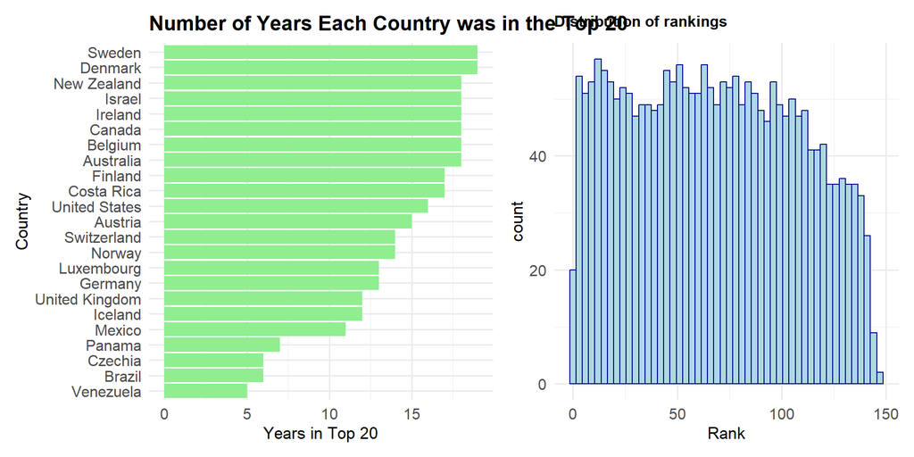

# Work Plan

The outcome is the Top-20 column and the predictors currently are all of the columns. The way we will answer the question is that we will attempt to find the most contributing variables in order to answer the question.

we will use a variety of methods to answer the question: SHAP variables,decision-tree and a logistic regression model, we will attempt to build those models concurrently and to compare and contrast them.

we would like to receive some conclusive results(the p_value of some of the variables will be significant),in all models so after comparison we could isolate the most relevant factors.

- Data preparation and cleaning. (Bar)
- Exploratory analysis and visualization. (Roni)
- Model building and evaluation. (Roni,Niv)
- Interpretation of results and final reporting. (Amal,Niv)

\

**models and fun** The main model: Decision Tree

Like logistic regression this is also a popular model for classification problems, and since it can be visualized it is an obvious choice to be one of the models.

The second model example: Logistic Regression

If we’re to take a classification route, then logistic regression would be a good model for that. We got good results, but again maybe too good. All of the predictors seem to be strong predictors which was good for the sake of showing that there is a correlation, but the performance was too accurate to use as the main model.

*decision tree models*

we will create 2 sets of 3 diffrent tree models the first set will include the following models: the first model will be a decision tree predicting the top_15 parameter and will use the chronologically split data. the second model will be a decision tree predicting the top_20 parameter and will use the chronologically split data. the third model will be a decision tree predicting the top_25 parameter and will use the chronologically split data.

the second set will include the following models: the first model will be a decision tree predicting the top_15 parameter and will use the randomly split data. the second model will be a decision tree predicting the top_20 parameter and will use the randomly split data. the third model will be a decision tree predicting the top_25 parameter and will use the randomly split data.

we start with chronologically spliting the data for prior and post 2022 in an almost 80-20 split

*first set*

*first model*

the first model training and pie chart of the factor importance

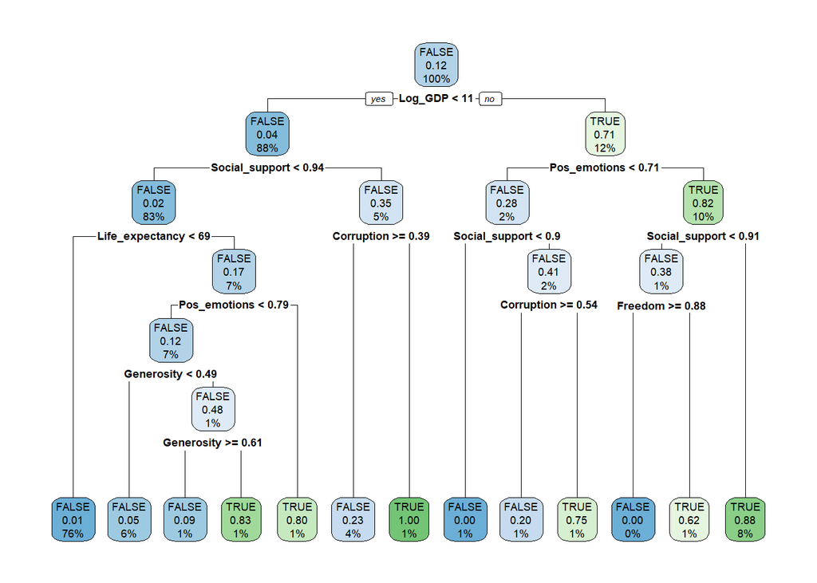

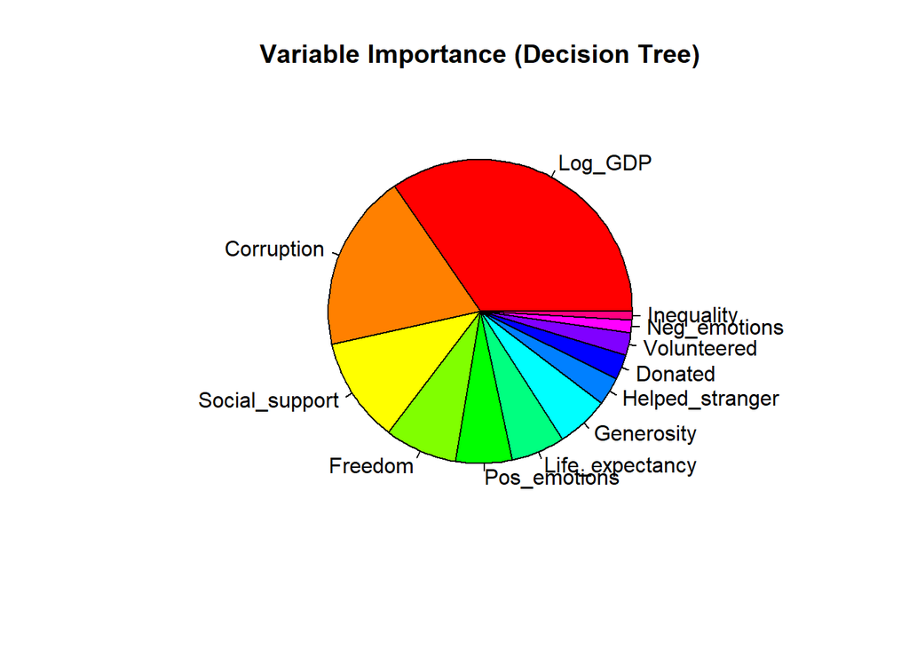

```
##          Actual
## Predicted FALSE TRUE
##     FALSE   332    9
##     TRUE     17   30
```

```
## Test Accuracy: 0.933
```

*second model* the second model training and pie chart of the factor importance

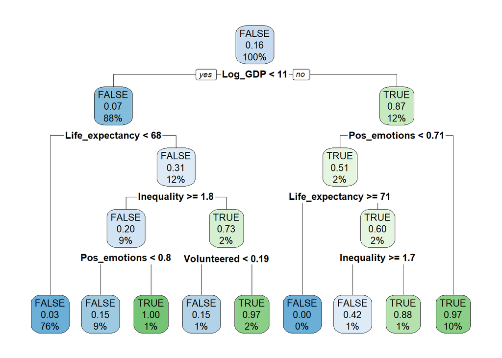

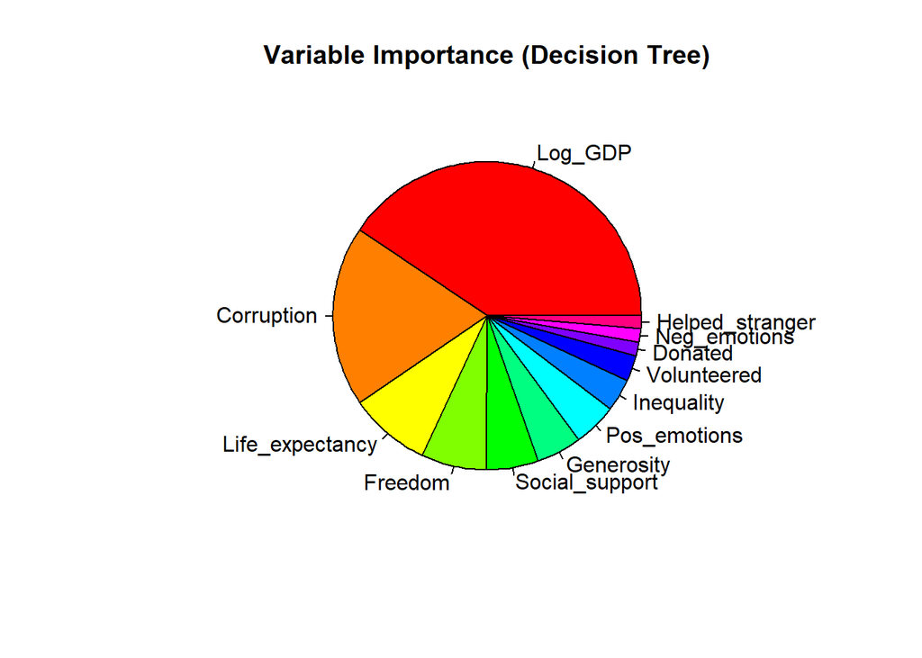

```
##          Actual
## Predicted FALSE TRUE
##     FALSE   329   12
##     TRUE      8   39
```

```
## Test Accuracy: 0.9485
```

*third model*